# Reproduce a paper with Distill

Example Distill R Markdown paper to use as a template for reproducible scientific and technical writing

Greg Chism https://gregtchism.netlify.app/ (Data Science Institiute, University of Arizona, Tucson AZ, USA)https://datascience.arizona.edu/  
2022-08-22

# Reproduce a paper with Distill

## R Markdown for paper reproduction

Scientific and technical writing is generally written using Word, or Google Docs. Think about whether you could reproduce these formats without copy and paste. You could always use LaTeX, but you’d have to learn the syntax.

### Why R Markdown?

- **Reproducibility**!
- Avoiding errors
- Several output options: PDF, HTML, Word, LaTeX
- Citation formatting made easy
- Collaboration
- Your documents will be prettier than most!

### Why [`distill`](https://www.rstudio.com/blog/distill/https://rstudio.github.io/distill/)?

There are several R Markdown templates to produce papers, such as those in [`rticles`](https://github.com/rstudio/rticles) and [`bookdown`](https://bookdown.org/yihui/bookdown/) These are basically all made to have a journal print format, which though is nice, **they aren’t always the best for electronic reading**.

Enter `distill`, a package that’s best known for designing websites using R Markdown. **You can however also write papers**! The output format is **very clean and readable**. Note that you can take all of your R Markdown script and paste it into another template if you wish.

Specific benefits:

- Reader-friendly that adapts to mobile devices
- Compatible with [LaTeX math](https://rstudio.github.io/distill/#equations), citations, and [footnotes](https://rstudio.github.io/distill/#footnotes-and-asides)
- Flexible [figure layout](https://rstudio.github.io/distill/figures.html) (larger width than article text)
- Attractively rendered [tables](https://rstudio.github.io/distill/tables.html)
- Support for [diagramming tools](https://rstudio.github.io/distill/diagrams.html)
- [Interactive visualizations](https://rstudio.github.io/distill/interactivity.html) through JavaScript and D3
- A variety of ways to [publish articles](https://rstudio.github.io/distill/publish_article.html), including sets of articles as a [Distill website](https://rstudio.github.io/distill/website.html) or as a [Distill blog](https://rstudio.github.io/distill/blog.html)

All of these features **help scientists communicate their work more efficiently through the web and R**.

## Workshop setup

### Install `distill` and other packages

```r
# Install pacman to install and load all others
install.packages("pacman")
```

```r
# Install & load all other packages
pacman::p_load(distill,
               ggpubr,
               ggthemes,
               here,
               kableExtra,
               rmarkdown,
               tidyverse)

# Set global ggplot() theme
theme_set(theme_pubclean(base_size = 16))

# Remove legend
theme_update(legend.position = "none")

# Shift axes title to their relative right
theme_update(axis.title = element_text(hjust = 1))

# Remove axes ticks
theme_update(axis.ticks = element_blank())

# Colorblind friendly palette
cbp1 <- c("#999999", "#E69F00", "#56B4E9", "#009E73",
          "#F0E442", "#0072B2", "#D55E00", "#CC79A7")
```

## Creating an article

Start by clicking `File > New File > R Markdown > From Template > Distill Article`

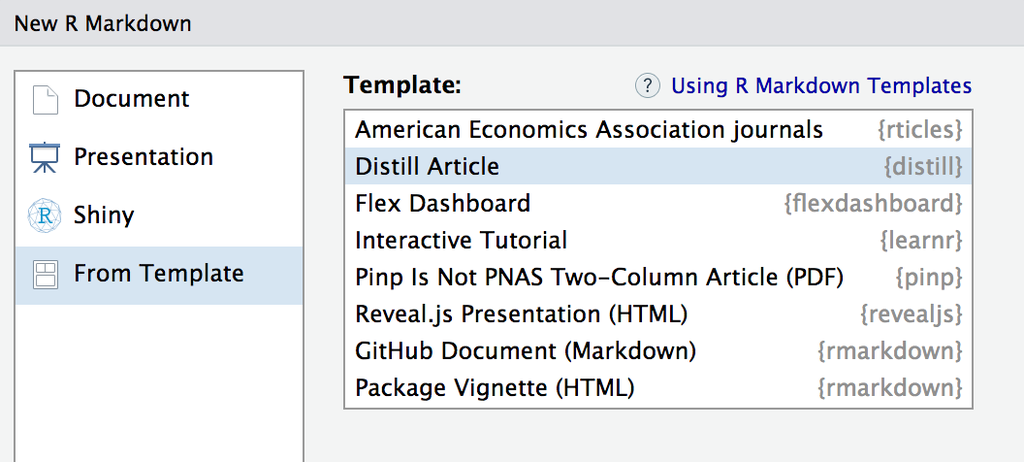

Alternatively, you can create a Distill article in the console

```r
distill::create_article("article.Rmd")
```

Distill articles include a title, description, data, author/affiliation, and bibliography in their YAML:

```
---
title: "Reproduce a paper with Distill"
description: |
  Example Distill R Markdown paper to use as a template for reproducible scientific and technical writing
author:
  - name: Greg Chism
    url: https://gregtchism.netlify.app/
    affiliation: Data Science Institiute, University of Arizona, Tucson AZ, USA
    affiliation_url: https://datascience.arizona.edu/
    orchid_id: 0000-0002-5478-2445
date: "2022-08-22"
output: distill::distill_article:
---
```

#### Author fields

- **Author names** - *required*, `first_name` and `last_name`, or a single `name` field (as above)
- **Author URL** - *required*, can be a GitHub, a personal website, departmental page, etc, specifid using `url`
- **Author affiliation** - *optional*, what entity are they affiliated with (university, company, agency, etc.), specified using `affiliation`.
- [**Orcid ID**](https://orcid.org/) - *optional*, researcher Orchid ID (e.g., Greg Chism: 0000-0002-5478-2445), specified using `orchid_id`

#### Date

The `date` field is denoted as month, day, year or as year, month, day (various notations are supported but only in these orders)

#### Bibliography

Denoded with the `bibliography` field, this refers to a Bibtex file that contains all sources cited in the article. See the citations resource for more information.

## Figures

Distill makes integrating figures into your article straightforward, where the default is the width of the article.

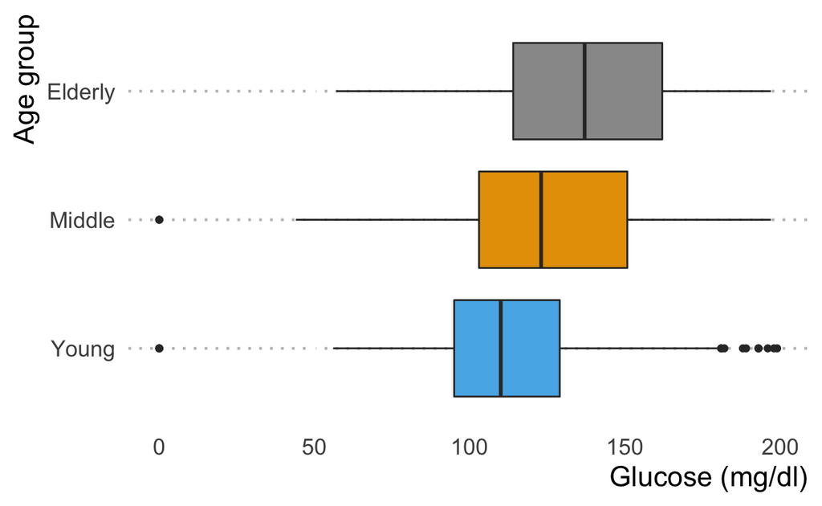

```r
data <- read.csv(here("Repro_Research_rrtools", "data", "diabetes.csv")) |>
    mutate(Age_group = ifelse(Age >= 21 & Age <= 30, "Young",
                            ifelse(Age > 30 & Age <= 50, "Middle",
                                   "Elderly")))

# Plot Glucose vs. Age group
data |>
  ggplot(aes(x = Glucose, y = fct_rev(Age_group), fill = Age_group)) +
    geom_boxplot() +
    xlab("Glucose (mg/dl)") +
    ylab("Age group") +
    scale_fill_manual(values = cbp1)
```

You can also add additional horizontal space if needed, which can be accomplished through the `layout` chunk.

```
{r layout="l-body-outset", fig.width=6, fig.height=2}
```

Note that when specifying a `layout` you should also specify an appropriate `fig.width` and `fig.height` for that layout. These values don’t determine the absolute size of the figure (that’s dynamic based on the layout) but they do determine the aspect ratio of the figure.

See the documentation on [figure layout](https://rstudio.github.io/distill/figures.html) for details on additional layout options.

## Tables

Distill articles can render several HTML options for displaying data frames. For example, `pages_table()` displays a page-able view of our `data`.

```r
data |>
    rmarkdown::paged_table()
```

| Pregnancies | Glucose | BloodPressure | SkinThickness | Insulin | BMI | DiabetesPedigreeFunction | Age | Outcome | Age_group |
| --- | --- | --- | --- | --- | --- | --- | --- | --- | --- |
| 6 | 148 | 72 | 35 | 0 | 33.6 | 0.627 | 50 | 1 | Middle |
| 1 | 85 | 66 | 29 | 0 | 26.6 | 0.351 | 31 | 0 | Middle |
| 8 | 183 | 64 | 0 | 0 | 23.3 | 0.672 | 32 | 1 | Middle |
| 1 | 89 | 66 | 23 | 94 | 28.1 | 0.167 | 21 | 0 | Young |
| 0 | 137 | 40 | 35 | 168 | 43.1 | 2.288 | 33 | 1 | Middle |
| 5 | 116 | 74 | 0 | 0 | 25.6 | 0.201 | 30 | 0 | Young |
| 3 | 78 | 50 | 32 | 88 | 31.0 | 0.248 | 26 | 1 | Young |
| 10 | 115 | 0 | 0 | 0 | 35.3 | 0.134 | 29 | 0 | Young |
| 2 | 197 | 70 | 45 | 543 | 30.5 | 0.158 | 53 | 1 | Elderly |
| 8 | 125 | 96 | 0 | 0 | 0.0 | 0.232 | 54 | 1 | Elderly |

[output cut: 758 more lines]

You can use `layout = "l-body-outset"` here as with the figure above to occupy more horizontal space than the article text. All of available [figure layout options](https://rstudio.github.io/distill/figures.html) work as expected for tables.

See the documentation on [table display](https://rstudio.github.io/distill/tables.html) for details on the various techniques available for rendering tables.

## Equations

Embedded math equations are supported via standard markdown [MathJax](https://www.mathjax.org/) syntax. For example, the following [LaTeX math](https://en.wikibooks.org/wiki/LaTeX/Mathematics):

```
$$
\sigma = \sqrt{ \frac{1}{N} \sum_{i=1}^N (x_i -\mu)^2}
$$
```

$$\sigma = \sqrt{ \frac{1}{N} \sum_{i=1}^N (x_i -\mu)^2}$$

## Citations

Bibtex is the supported way to make academic citations. To include citations, first create a bibtex file and refer to it from the `bibliography` field of the YAML front-matter (as [illustrated above](https://rstudio.github.io/distill/#front-matter)).

For example, your bibliography file might contain:

```
@Book{xie2015,
  title = {Dynamic Documents with R and knitr},
  author = {Yihui Xie},
  publisher = {Chapman and Hall/CRC},
  address = {Boca Raton, Florida},
  year = {2015},
  edition = {2nd},
  note = {ISBN 978-1498716963},
  url = {http://yihui.name/knitr/},
}
```

Citations are made in the article text with R Markdown notation (e.g., `@xie2015`), which refers to the ID provided in the bibliography. Multiple IDs can be provided, separated by semicolons.

If you have an appendix, a bibliography is automatically created and populated in it.

See the article on [citations](https://rstudio.github.io/distill/citations.html) for additional details on using citations, including how to provide the metadata required to make your article more easily citable for others.

## Footnotes and asides

Footnotes use Pandoc markdown notation, for example `^[This will become a hover-able footnote]`. The number of the footnote will be automatically generated. [^1]

Notes can also be made in the gutter of the article (to the right of article text), done using the `<aside>` tag.

This content will appear in the gutter of the article.

You can also include figures in the gutter, done by enclosing the code chunk which generates the figure within `<aside>` tags:

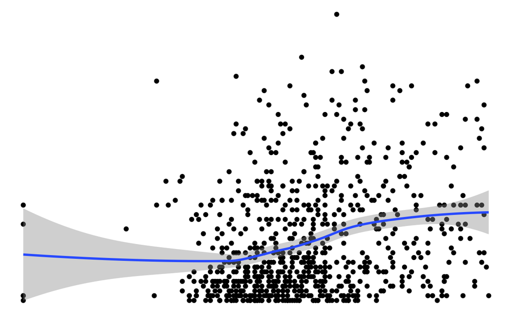

You can add a table of contents using the `toc` option and specify the depths of headers that it will occupy using `toc_depth` option.

```
---
title: "Reproduce a paper with Distill"
description: |
  Example Distill R Markdown paper to use as a template for reproducible scientific and technical writing
output: distill::distill_article:
    toc: true
    toc_depth: 2
---
```

The default table of contents depth is 3, so there will be levels 1, 2, and 3 headers included in the table of contents.

The table of contents automatically floats to the left when the article is displayed at 1000px wide or greater. To show the table of contents on top, specify `toc_float: false`

```
output:
  distill::distill_article:
    toc: true
    toc_float: false
```

## Code blocks

Distill does not show the code for chunks from which an output is produced (`knitr` option `echo = FALSE`)

`echo = FALSE` reflects that Distill articles often present the results of analyses and not the underlying code. By setting `echo = TRUE`, the code will also be displayed.

```r
1 + 1
```

```
[1] 2
```

You can also include code that is only displayed by specifying `eval = FALSE`

```r
1 + 1
```

There are several default values that Distill uses for `knitr` chunk options (these defaults also reflect the use case of presenting results/output rather than underlying code):

| Option | Value | Comment |
| --- | --- | --- |
| `echo` | `FALSE` | Don’t print code by default. |
| `warning` | `FALSE` | Don’t print warnings by default. |
| `message` | `FALSE` | Don’t print R messages by default. |
| `comment` | `NA` | Don’t preface R output with a comment. |
| `R.options` | `list(width = 70)` | 70 character wide console output. |

Keeping R code and output at 70 characters wide (or less) is best for readability across devices and screen sizes.

The defaults can be overridden for each code chunk, but you can also set global default. *Note that a ‘#’ is in place to prevent it from running in the document*.

`#{r setup, include = FALSE} knitr::opts_chunk$set( echo = TRUE, warning = TRUE, message = TRUE, comment = "##", R.options = list(width = 60) )`

## Code folding

`code_folding` can be used to hide code by default but readers can optionally show it.

```
---
title: "Reproduce a paper with Distill"
description: |
  Example Distill R Markdown paper to use as a template for reproducible scientific and technical writing
output: distill::distill_article:
    code_folding: true
---
```

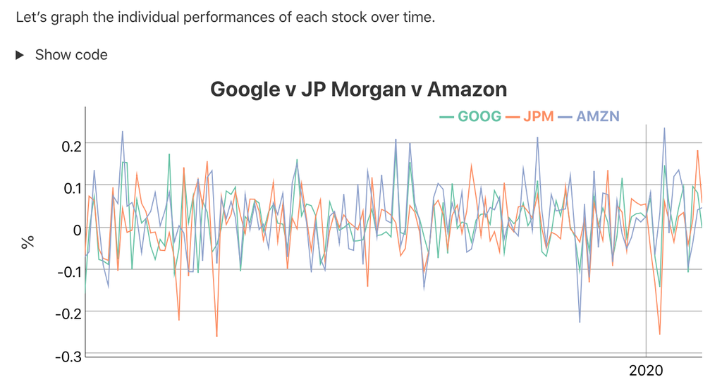

*Retrieved from https://rstudio.github.io/distill*

You can also make `code_folding` a per-chunk basis

```r
1 + 1
```

Provide a string rather than `TRUE` to customize the caption (the default is “Show code”).

## Syntax highlighting

Syntax highlighting for R code is done via the [`downlit`](https://downlit.r-lib.org/) package, which provides automatic linking of R functions to their online documentation. By default, highlighting is done using colors [optimized for accessibility and color contrast](https://www.a11yproject.com/).

You can customize highlighting behavior using the `highlight` and `highlight_downlit` options. For example, to use the Pandoc “haddock” highlighting theme and disable the use of `downlit`, you would do this:

```
---
title: "Reproduce a paper with Distill"
description: |
  Example Distill R Markdown paper to use as a template for reproducible scientific and technical writing
output: distill::distill_article:
          highlight: haddock
          highlight_downlit: false
---
```

Available options for `highlight` include:

| Option(s) | Description |
| --- | --- |
| `default` | Default (accessible) theme |
| `rstudio` | RStudio editor theme |
| `haddock`, `kate`, `monochrome`, `pygments`, `tango` | Pandoc highlighting [themes](https://www.garrickadenbuie.com/blog/pandoc-syntax-highlighting-examples/). |
| Path to `.theme` file | Custom Pandoc [theme file](https://pandoc.org/MANUAL.html#syntax-highlighting). |

## Appendices

Appendices can be added after your article by adding the `.appendix` class to any level 1 or level 2 header. For example:

```html
## Acknowledgments {.appendix}
This is a place to recognize people and institutions. It may also be a good place to acknowledge and cite software that makes your work possible.

## Author Contributions {.appendix}
We strongly encourage you to include an author contributions statement briefly describing what each author did.
```

Footnotes and references will be included in the same section, immediately beneath any custom appendices.

## Theming

The appearance of a Distill article can be customized using a theme and CSS just like Distill sites and blogs. You can use the `create_theme()` function to add a theme CSS file in the current working directory.

For example:

```
create_theme(name = "theme")
```

Read more about how to customize a Distill theme. To apply a custom theme to an article, add a `theme` key to your article’s YAML front-matter:

```yaml
---
title: "The Sharpe Ratio"
output:
  distill::distill_article:
    toc: true
    theme: theme.css
---
```

One of the fastest ways to change the default appearance is to use custom Google fonts. To do this, you need to do two things:

1. Embed the font using the @import method, and
2. Specify the font in the CSS file.

You can do both of these things inside your `theme.css` file. For example, here is an article styled with the demo theme detailed here.

### Screenshot

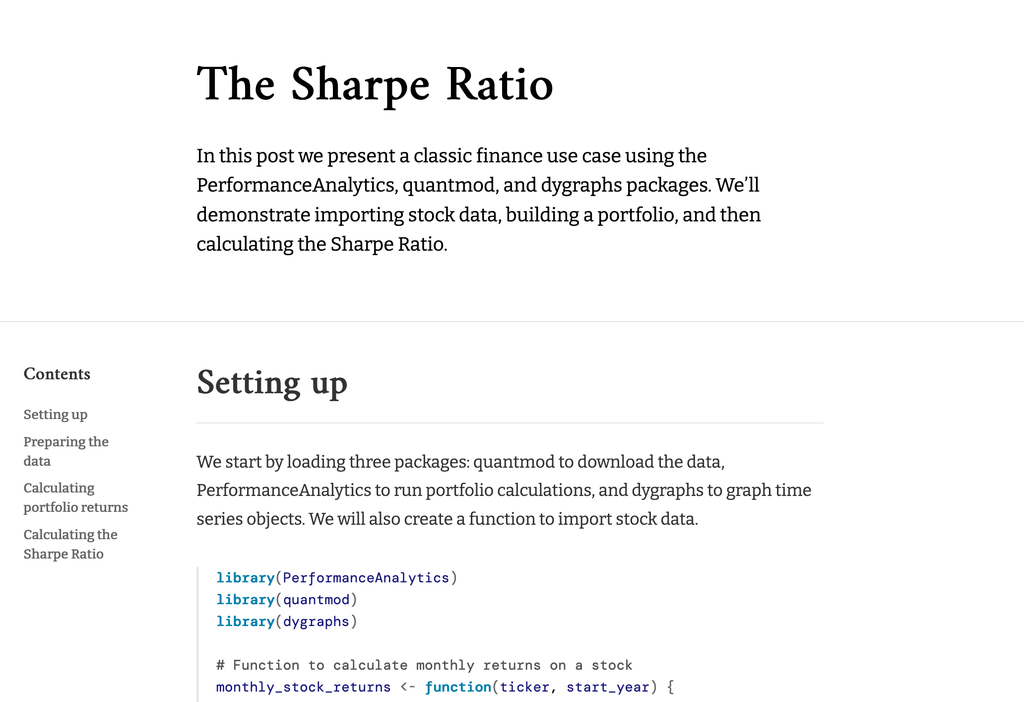

### theme.css snippet

```
/* base variables */
/* Edit the CSS properties in this file to create a custom
   Distill theme. Only edit values in the right column
   for each row; values shown are the CSS defaults.
   To return any property to the default,
   you may set its value to: unset
   All rows must end with a semi-colon.                      */
/* Optional: embed custom fonts here with `@import`          */
/* This must remain at the top of this file.                 */
@import url('https://fonts.googleapis.com/css2?family=Amiri');
@import url('https://fonts.googleapis.com/css2?family=Bitter');
@import url('https://fonts.googleapis.com/css2?family=DM+Mono');
html {
  /*-- Main font sizes --*/
  --title-size:      50px;
  --body-size:       1.06rem;
  --code-size:       14px;
  --aside-size:      12px;
  --fig-cap-size:    13px;
  /*-- Main font colors --*/
  --title-color:     #000000;
  --header-color:    rgba(0, 0, 0, 0.8);
  --body-color:      rgba(0, 0, 0, 0.8);
  --aside-color:     rgba(0, 0, 0, 0.6);
  --fig-cap-color:   rgba(0, 0, 0, 0.6);
  /*-- Specify custom fonts ~~~ must be imported above   --*/
  --heading-font:    "Amiri", serif;
  --mono-font:       "DM Mono", monospace;
  --body-font:       "Bitter", sans-serif;
  --navbar-font:     "Amiri", serif;
}
/* More properties ... */
```

## Acknowledgments

Taken from the original source

Distill for R Markdown builds on the work of many individuals and projects. [Shan Carter](https://github.com/shancarter), [Ludwig Schubert](https://github.com/ludwigschubert), and [Christopher Olah](https://github.com/colah) created the Distill web framework. [John MacFarlane](https://github.com/jgm) created the Pandoc universal markup converter. [Davide Cervone](https://github.com/dpvc) and [Volker Sorge](https://github.com/zorkow) created the MathJax library for rendering mathematical notation on the web. [Mike Bostock](https://github.com/mbostock) created the D3 library for producing dynamic, interactive data visualizations for the web. We are grateful for the spirit of generosity that moved these individuals to create high-quality open source software for the benefit of all.

## Disclaimer

This content was inspired by and duplicated under [CC BY 4.0](https://creativecommons.org/licenses/by/4.0/):

```
Allaire, et al. (2018, Sept. 10). Distill for R Markdown. Retrieved from https://rstudio.github.io/distill
```

Much of the content was modified either completely or slightly to condense the material and to utilize different data, however some content was duplicated completely.

[^1]: This will become a hover-able footnote